# ggplot

A. M. Machno

27 kwietnia 2018

## Po co robić wykresy?

Graficzna prezentacja danych ma dwa cele i w każdym z nich mamy całkiem różne wyzwania.

- **Wykresy odkrywcze** (*exploratory graphs*): wykresy mające na celu poznanie zbioru danych przez badacza. Na tym etapie bardzo często powstaja hipotezy badawcze, które moga zostać zweryfikowane metodami statystycznymi.
- **Wykresy objaśniające** (*explanatory graphs*): wykresy mojące na celu wizualizację otrzymanych wyników. Wykresy te sa elementem komunikacji wyników.

## Przykładowy wykres `ggplot`

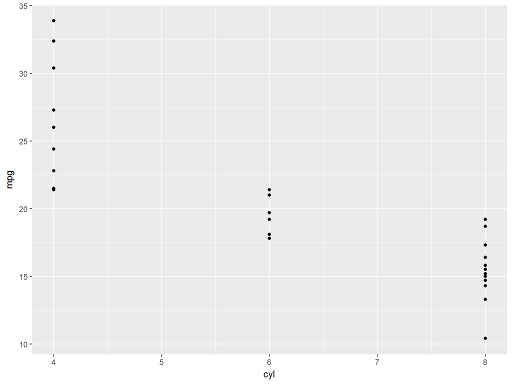

## Elementy gramatyki grafiki

- **Dane**: zbiór danych, który chcemy przedstawić na wykresie.
- **Estetyka** (*aesthetics*): skale na które mapowane są dane.
- **Geometrie**: elementy graficzne użyte do przedstawienia danych.
- **Płaszczyzny** (*facets*): tworzy wiekrotność wykresu.
- **Statystyki**: representacje danych pomagające w zrozumieniu lub ukazaniu prawidłowości.
- **Współrzędne**: powierzchnia na której mają być stworzone wykresy.
- **Motyw**: wszystkie elementy nie związane z danymi.

## Estetyki

Przeważnie na jednym wykresie w skład estretyk wchodzi wiele alementów. Najbardziej popularnymi estetykami są:

- `x`, `y`: określa, które elementy danych mają konkretne współrzędne. Podstawowe estetyki, występujące prawie w każdym wykresie.
- `color`, `fill`: kolory odpowiednio brzegu oraz wnętrza geometrii. - `size`: wielkość.
- `labels`: określa, wartości tekstowe, które mogą być przekazane do geometrii tekstowych.
- `alpha`: przezroczystość geometrii. Wartość zero oznacza całkowicie przezroczysty obiekt, wartość jeden całkowicie wypełniony kolorem.
- `shape`: kształt.

**Uwaga**: w estetyce każda z powyższych charakterystyk musi być przypisana do elementu danych, wtedy tworzy estetykę.

## Pakiet `ggplot2`

Podstawową funkcją pakietu `ggplot2` jest `ggplot()`. Najprostrzym użyciem funkcji jest określenie zbioru danych oraz estetyk. W wyniku otrzymamy obiekt, który graficzny, ale nie posiadający części geometrycznej.

Dodatkowym elementem wymaganym, aby obiekt mógł być wyświetlony jest geometria. Dodanie kolejnego elementu do obiektu graficznego odbywa się poprzez dodanie wartości do istniejącego obiektu graficznego. W ten sposób można dodawać kolejne warstwy do obiektu graficznego. Wywołanie tegoż obiektu skutkuje stworzeniem grafiki.

**Uwaga**: aby obiekt graficzny mógł zostać wyświtlony wymagane są przynajmiej: **dane**, **estetyki** oraz **geometrie**.

## Estetyki `x`, `y` i `color`

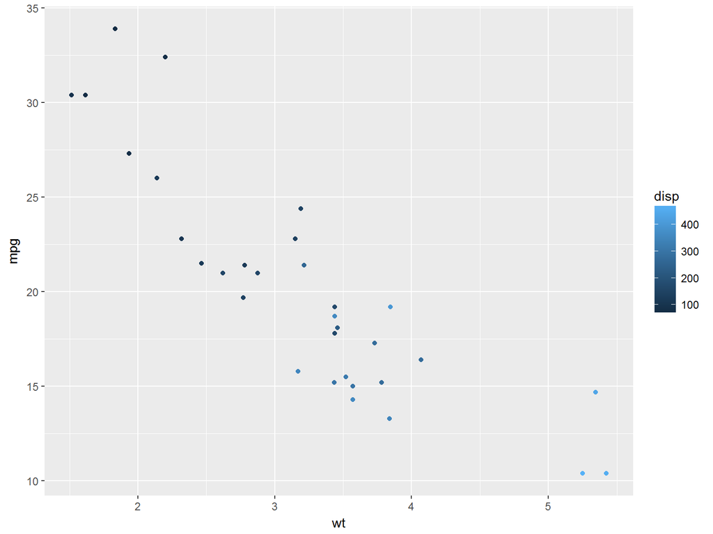

## Estetyka `size`

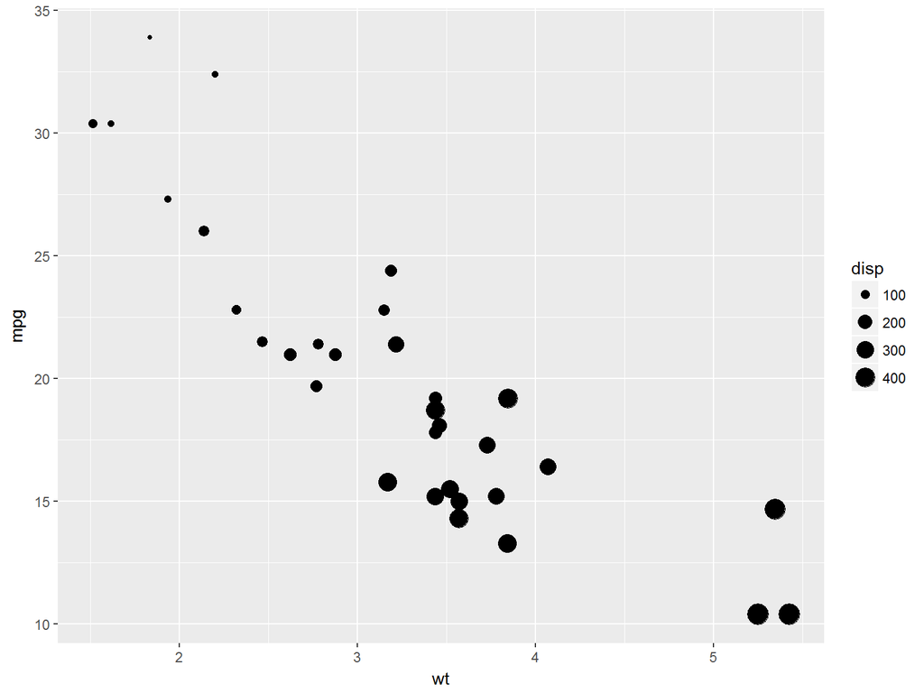

## Dodatkowa geometria

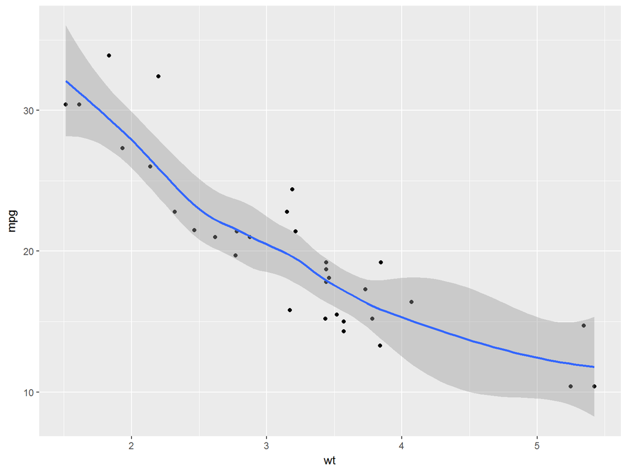

## Estetyka color z dodatkową geometrią

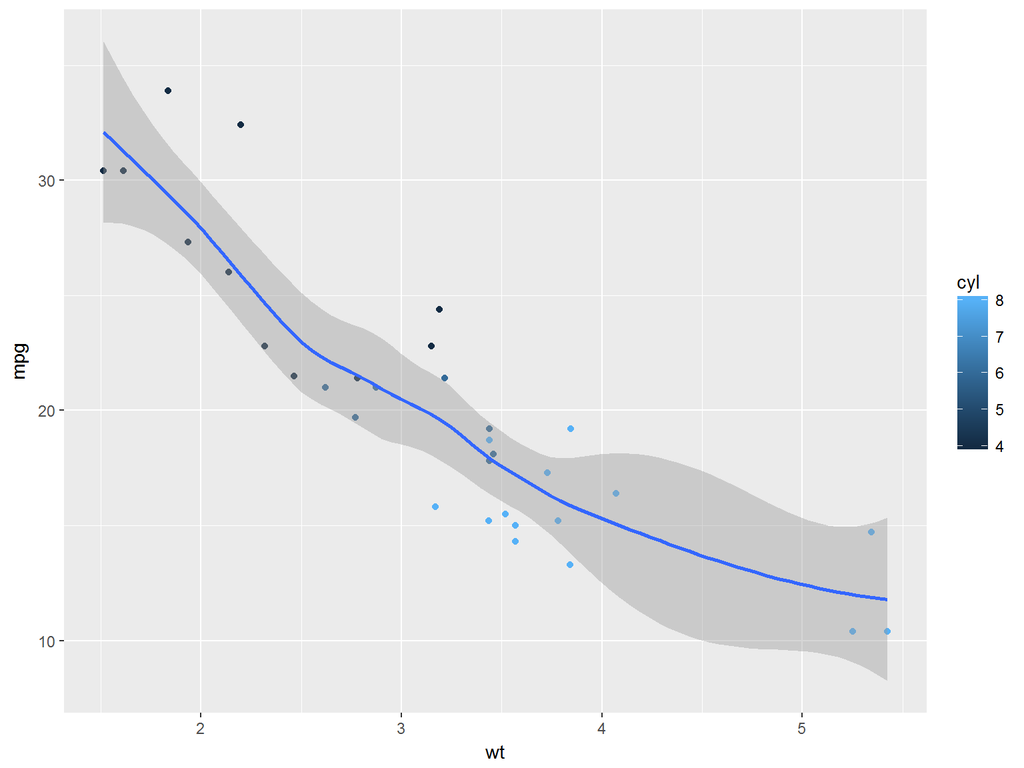

## Estetyka color dla kategorii z dodatkową geometrią

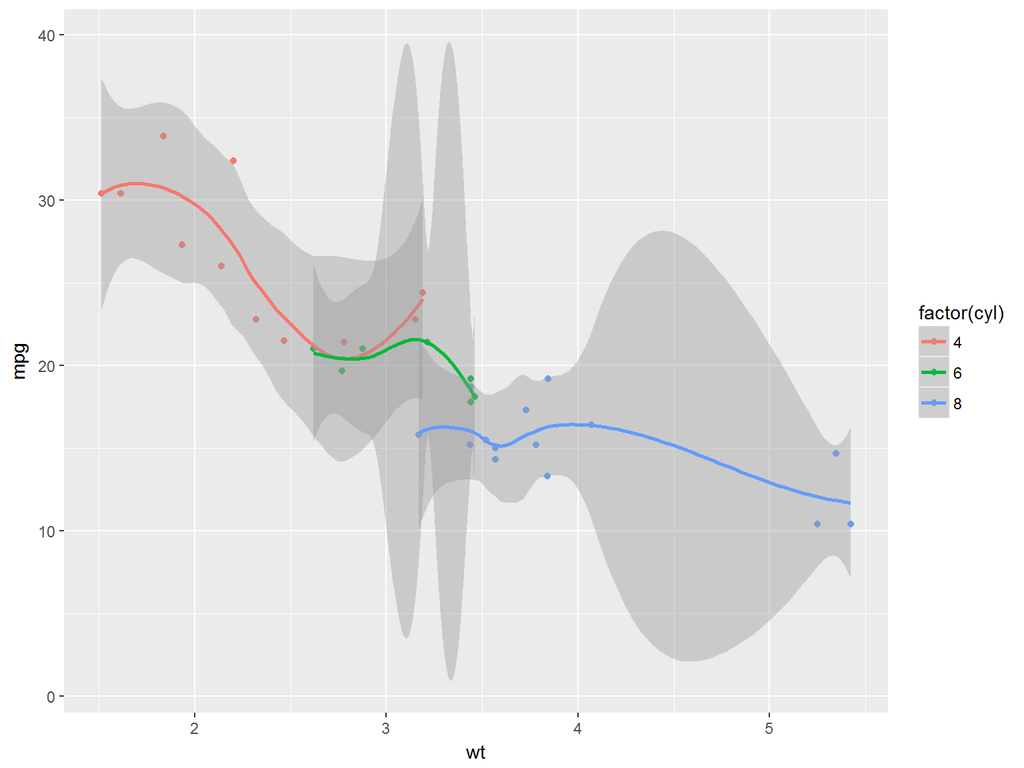

## Różne estetyki dla różnych geometrii

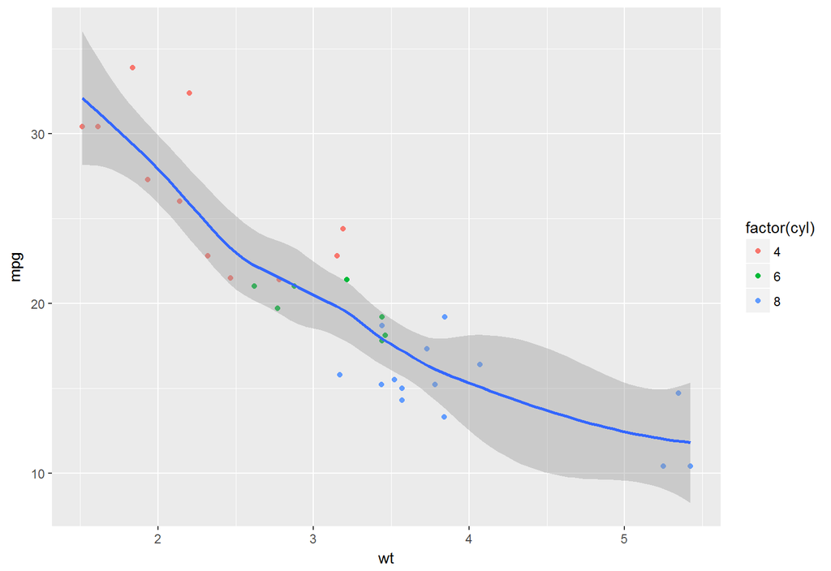

## Atrybuty geometrii

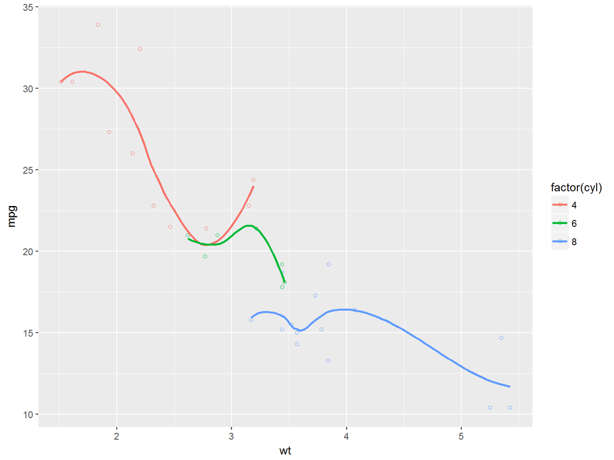

## Przykłady płaszczyzn

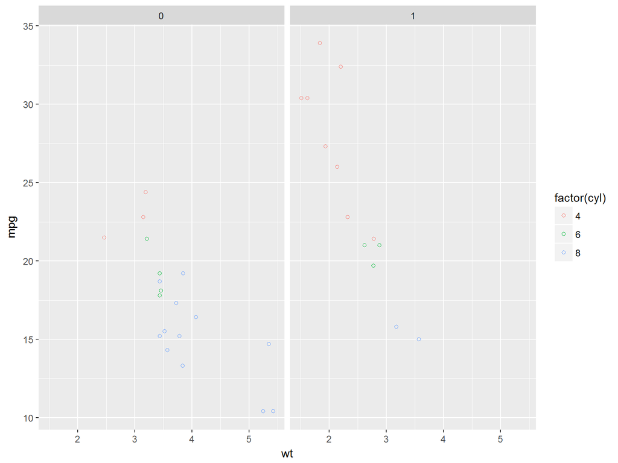

## ćwiczenia

1. Dla danych `diamonds` naszkicować wykres punktowy ceny od wagi.
2. Do wykresu z 1. dodać prostą obrazującą zależność liniową.
3. Dla wykresu z 1. określić kolor punktów w zależności od klarowności diamentu.
4. Do wykresu z 3. dodać wygładzone linie opisujące zależność bez zacieniowanych obszarów obisujących błędy estymacji tych krzywych dla każdej z klarowności. Niech klasa cięcia będzie reprezentowana przez kszałt punktu.

## Dane do wizualizacji.

W związku ze specjalną strukturą tworzenia wykresów w pakiecie `ggplot`, tzn. korzystanie z koncepcji gramatyki grafiki, dla każdego rodzaju wykresu może być potrzebna inna reprezentacja danych.

Przede wszystkim, funkcja `ggplot` w inny sposób traktuje zmienne różnego typu. Najczęstszym przypadkiem możliwych róznic w reprezentacji są zmienne liczbowe `integer` oraz zmienne kategoryczne.

Każda estetyka jest skalą związaną ze zmienną w danych. Jeżeli wielkość nas interesująca jest rozbita na dwie kolumny lub więcej niż jeden element występuje w jednej kolumnie, dane należy zmodyfikować.

## Dane `iris`

Dane `iris` są to dane 150 kwiatków trzech gatunków. Mierzonymi wielkościami są długości oraz szerokości płatków oraz działek kielicha. W kilku kolejenych slajdach zaprezentowane zostaną konkretne wykresy, a potem odtworzone poprzez modyfikację danych oraz wywołanie funkcji `ggplot()`

```
## 'data.frame':    150 obs. of  5 variables:
##  $ Sepal.Length: num  5.1 4.9 4.7 4.6 5 5.4 4.6 5 4.4 4.9 ...
##  $ Sepal.Width : num  3.5 3 3.2 3.1 3.6 3.9 3.4 3.4 2.9 3.1 ...
##  $ Petal.Length: num  1.4 1.4 1.3 1.5 1.4 1.7 1.4 1.5 1.4 1.5 ...
##  $ Petal.Width : num  0.2 0.2 0.2 0.2 0.2 0.4 0.3 0.2 0.2 0.1 ...
##  $ Species     : Factor w/ 3 levels "setosa","versicolor",..: 1 1 1 1 1 1 1 1 1 1 ...
```

## Wykres I

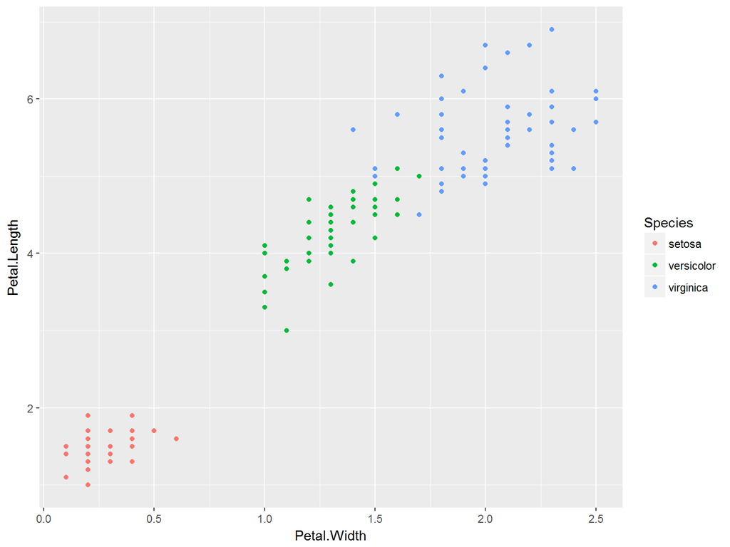

## Dane do wykresu I

Oryginalne dane `iris` sa odpowiednie do tego wykresu, zmienna na osi *x* oraz osi *y* są w kolumnach, oraz zmienna określająca koloró również.

Czy te dane nadały by się aby stworzyć obok siebie wykresy długości od szerekości płatków oraz działek kielicha?

## Wykres II

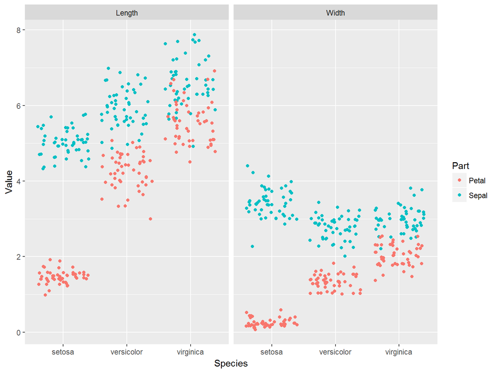

## Dane do wykresu II

```
## 'data.frame':    600 obs. of  4 variables:
##  $ Species: Factor w/ 3 levels "setosa","versicolor",..: 1 1 1 1 1 1 1 1 1 1 ...
##  $ Part   : chr  "Sepal" "Sepal" "Sepal" "Sepal" ...
##  $ Measure: chr  "Length" "Length" "Length" "Length" ...
##  $ Value  : num  5.1 4.9 4.7 4.6 5 5.4 4.6 5 4.4 4.9 ...
```

## Stworzenie wykresu II

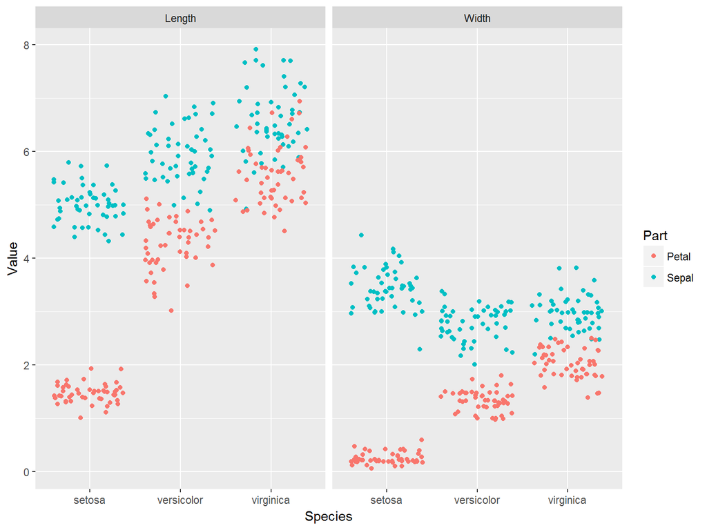

## Wykres III

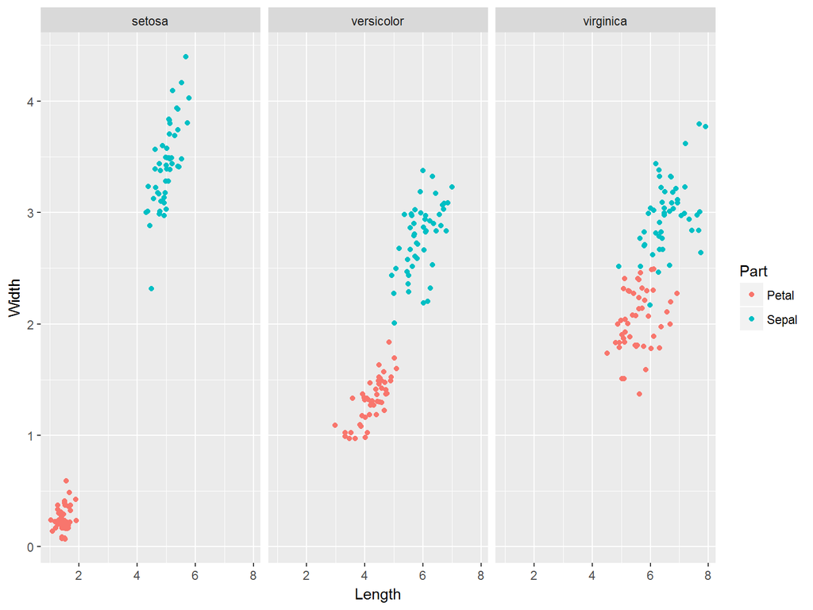

## Dane do wykresu III

```
## 'data.frame':    300 obs. of  5 variables:
##  $ Species: Factor w/ 3 levels "setosa","versicolor",..: 1 1 1 1 1 1 1 1 1 1 ...
##  $ Flower : int  1 1 2 2 3 3 4 4 5 5 ...
##  $ Part   : chr  "Petal" "Sepal" "Petal" "Sepal" ...
##  $ Length : num  1.4 5.1 1.4 4.9 1.3 4.7 1.5 4.6 1.4 5 ...
##  $ Width  : num  0.2 3.5 0.2 3 0.2 3.2 0.2 3.1 0.2 3.6 ...
```

## Stworzenie wykresu III

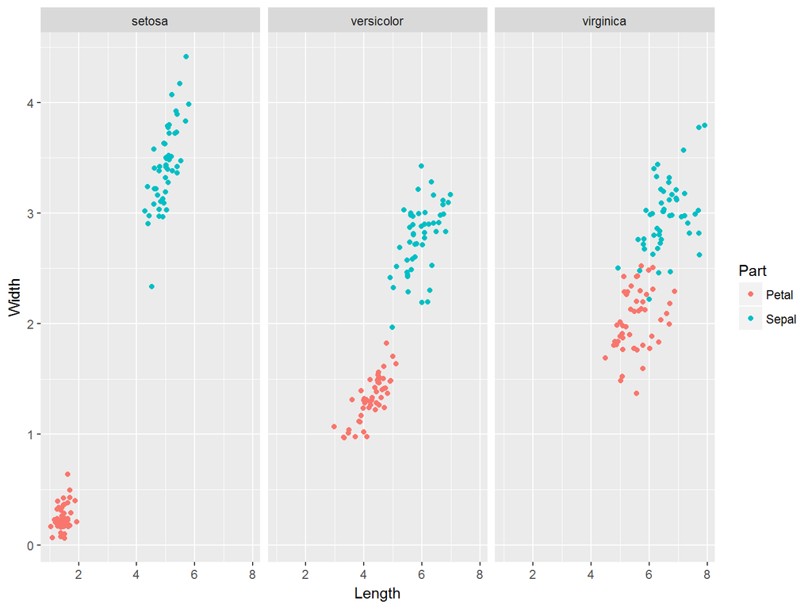

## Ćwiczenia

1. Dla danych `hflights` stworzyć wykres opóźnienia (oba typy: `DepDelay` oaz `ArrDelay`) od czasu podróży. Niech kształt punktów będzie zależny d rodzaju opóżnienia (wylot i przylot), a wielkość punktów od odległości lotu. Dotakowo niech obramowanie punktów będzie kolorowane w zależności od przewoźnika.
2. Co można zmodyfikować w wykresie 1. aby był bardziej czytelny?
3. Dla danych `hflights` stworzyć wykres czasu jazdy taksówką (oba typy: `TaxiIn` oaz `TaxiOut`) od daty. Niech kształt punktów określa typ jazdy taksówką, a wielkość punków odległość lotu. Dodatkowo storzyc krzywe opisujące zależność w grupach przewoźników.

## Estetyki

W koncepcji Gramatyki Grafiki, estetyki nie są atrybutami wizualnymi, a mapowaniami zmiennych na elementy wizualne.

- Estetyki pozwalaja zamieścić kilka zmiennych na jednym wykresie.
- Atrybuty, używane wewnątrz geometrii, są, przeciwieństwie do estetyk przypisanymi wartościami elementów graficznych.

## Kolor jako atrybut

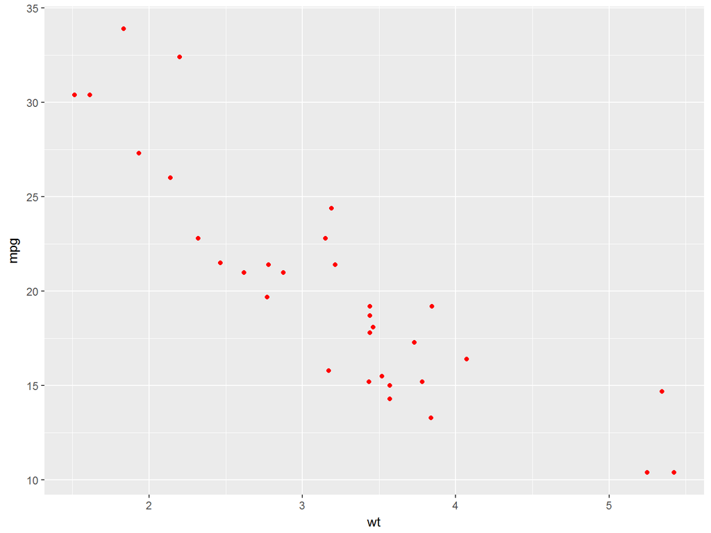

## Kolor jako estetyka

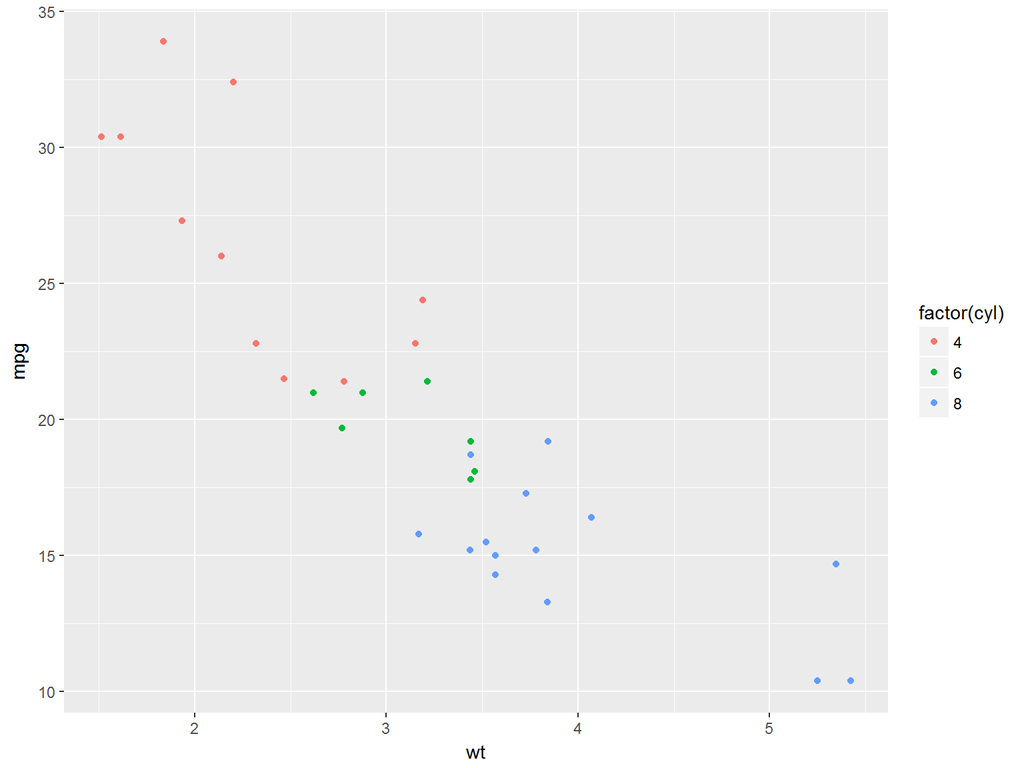

## Najczęstsze estetyki

- x: pozycja na osi X
- y: pozycja na osi Y
- colour: kolor kropek, kontur innych kształtów
- fill: kolor wnętrza
- size: średnica grubość lini
- alpha: przezroczystość (0- w pełni przezroczysty, 1- zuepełnie nieprzezroczysty)
- linetype: wzór linii
- labels: tekst na osiach wykresu
- shape: szktałt

## Długość płatka od gatunku kwiatu

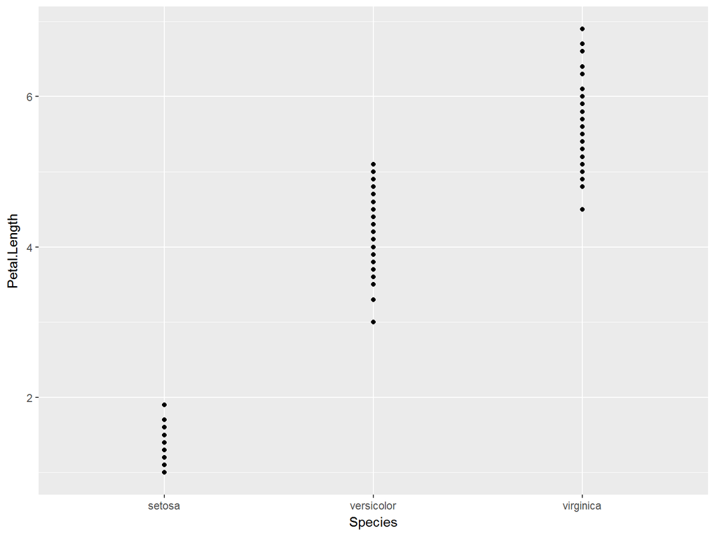

## Długość i szerokość płatka od gatunku

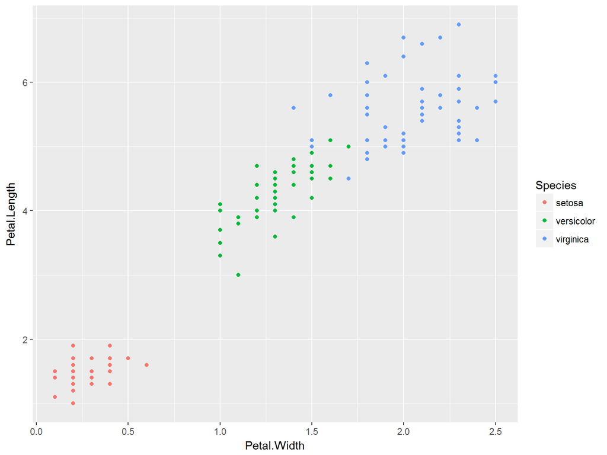

## Dodatnie atrybutów ulepszających

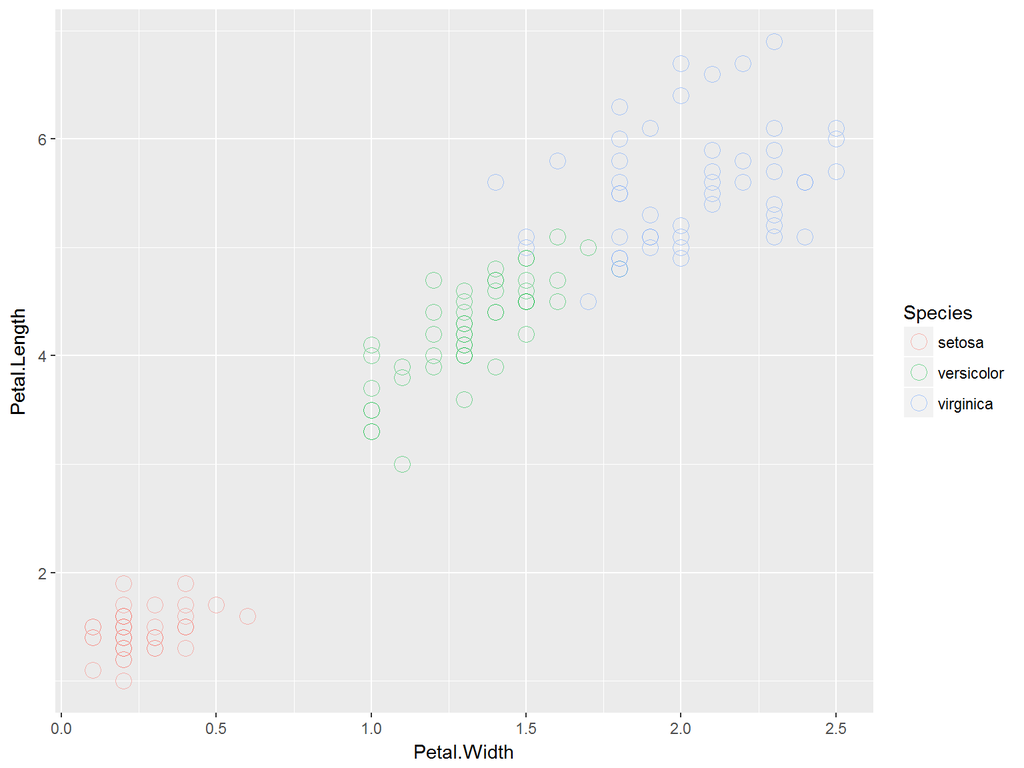

## Wyświetlanie etykiet

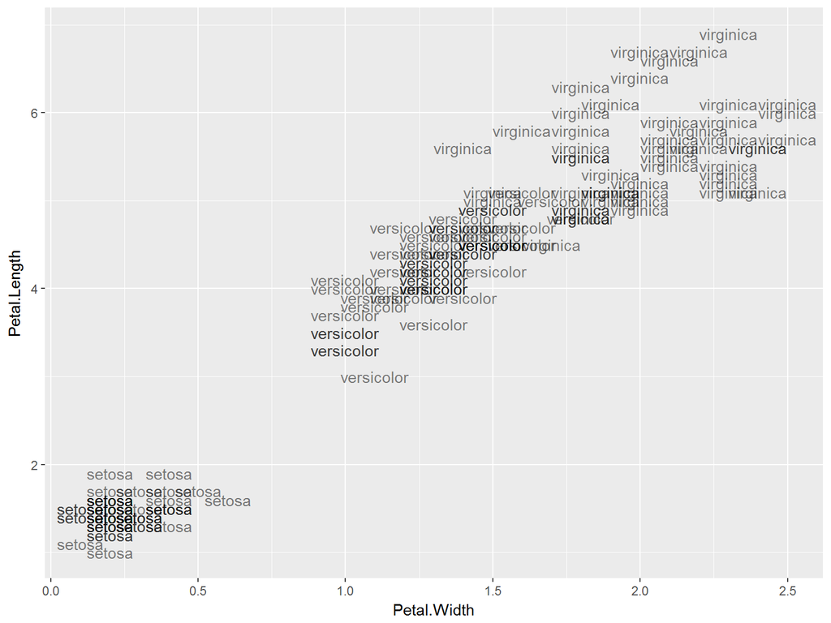

## Kolizja atrybutu z estetyką

## Kolizja atrybutu z estetyką

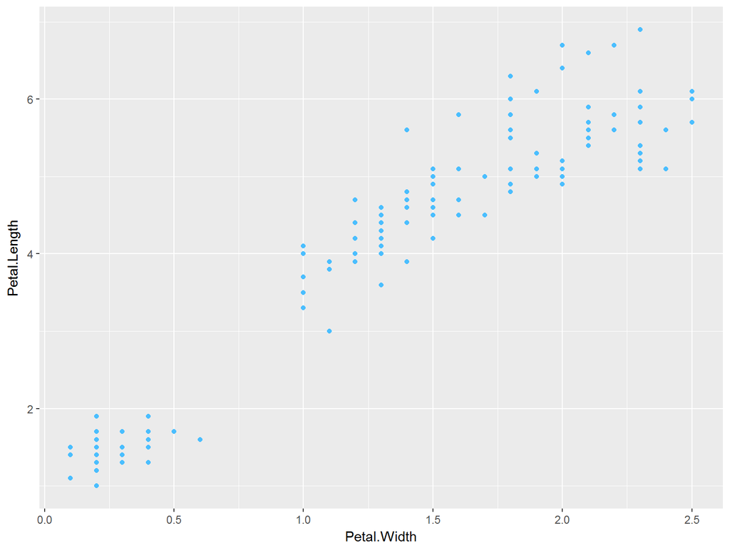

## Wypełnienie a kolor

## Kolizja atrybutu z estetyką

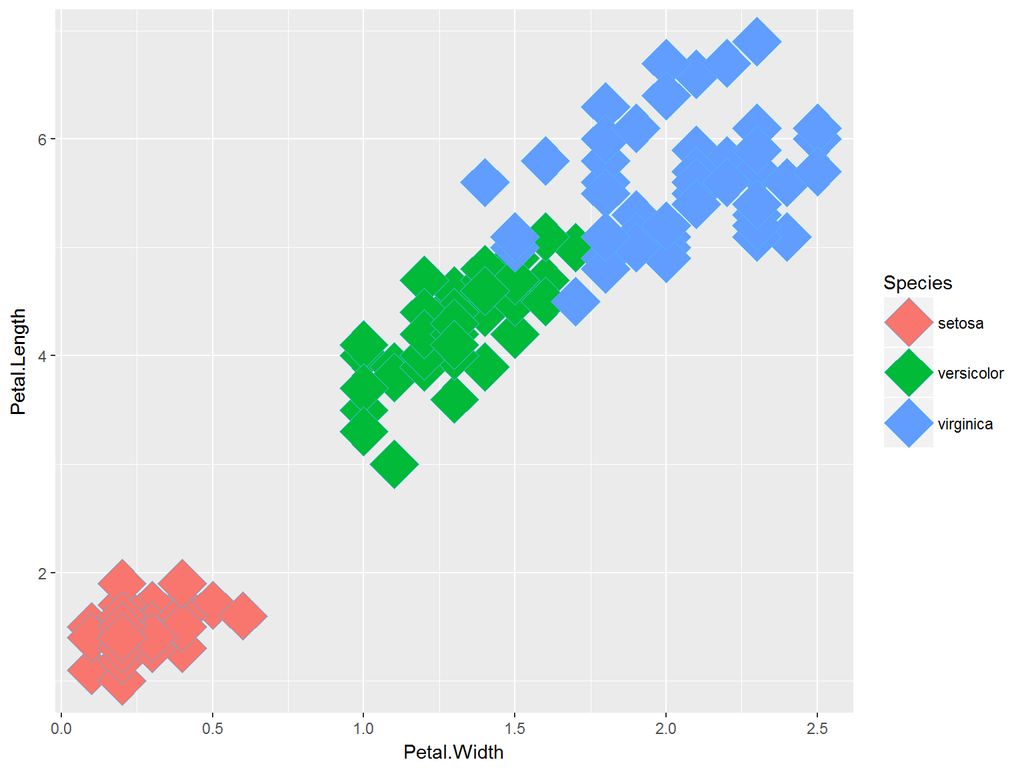

## Wyświetlanie tekstu

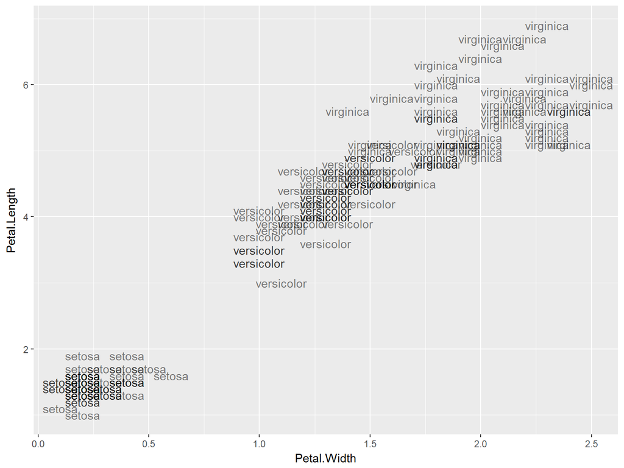

## Ćwiczenia

1. Dla danych **mtcars** stworzyć wykres zależności pomiędzy wagą a spalaniem. Niech kolor punktów określa liczbę cylindrów i niech zależności dla różnego tpy skrzyń biegów będą na innych płaszczyznach.
2. Dla danych **mtcars** stworzyć wykres zależności mocy od pojemności silnika. Niech na wykresie pojawiają się napisy z nazwami tych samochodów.

## Pozycje

Aby określić w jaki sposób wyświtlać nakładające się elementy na wykresie, używamy pozycji. Przykładowymi pozycjami są:

- identity: domyślna wartość dla wykresu punktowego.
- dodge: w wykresie słupkowym, ustawia słupki dla różnych grup obok siebie.
- stack: domyślna pozycja dla wykresów słupkowych, ustawia słupki dla różnych grup na sobie.
- fill: w wykresie słupkowym,ustawia słupki dla różnych grup na sobie achowująca wysokość.
- jitter: “drganie”, pozwala na zauważenie punktów, które są w tym samym miejscu. Siłę drgania możemy stalić argumentami *width* oraz *hight*.
- jitterdodge: przede wszystkim używane dla punktów występujących z wykresami pudełkowymi.

## stack

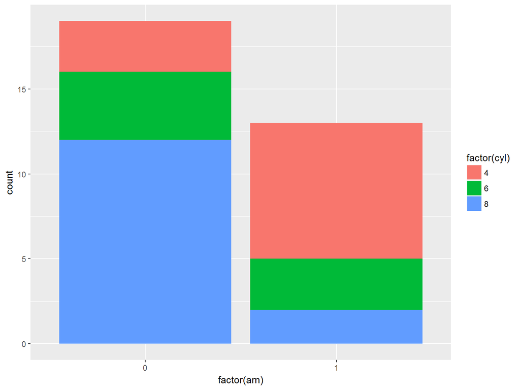

## fill

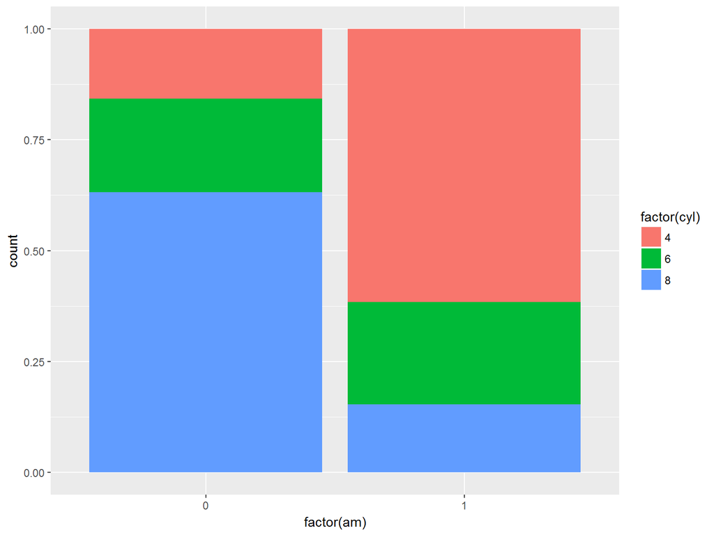

## dodge

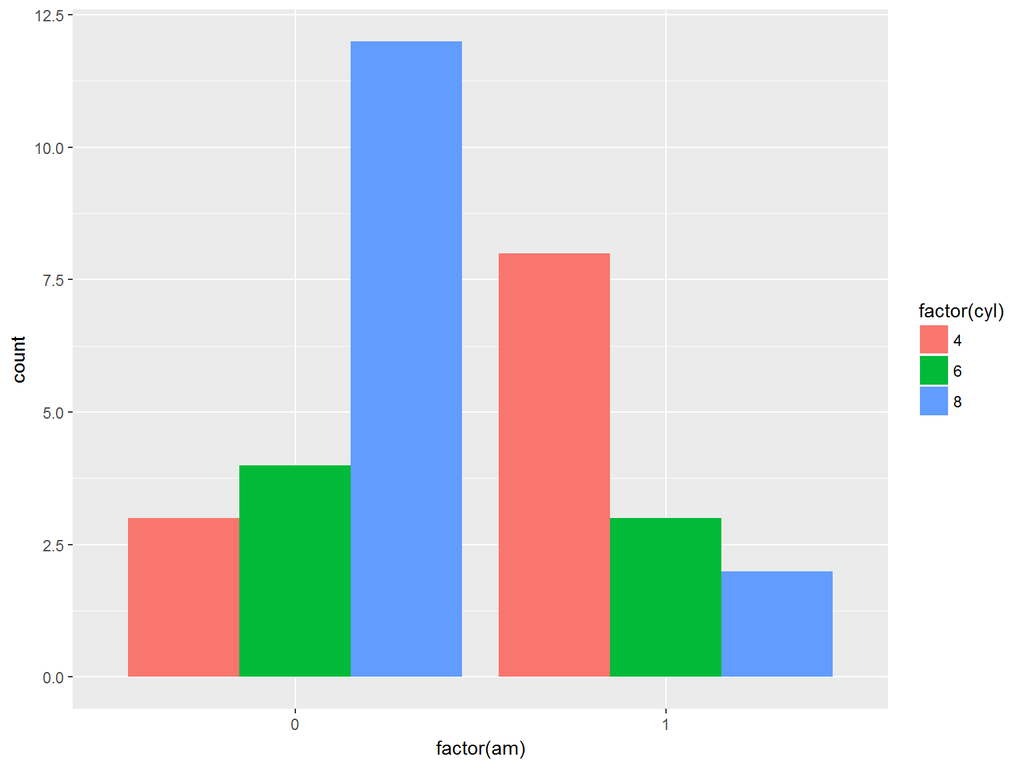

## Pozycja dodge

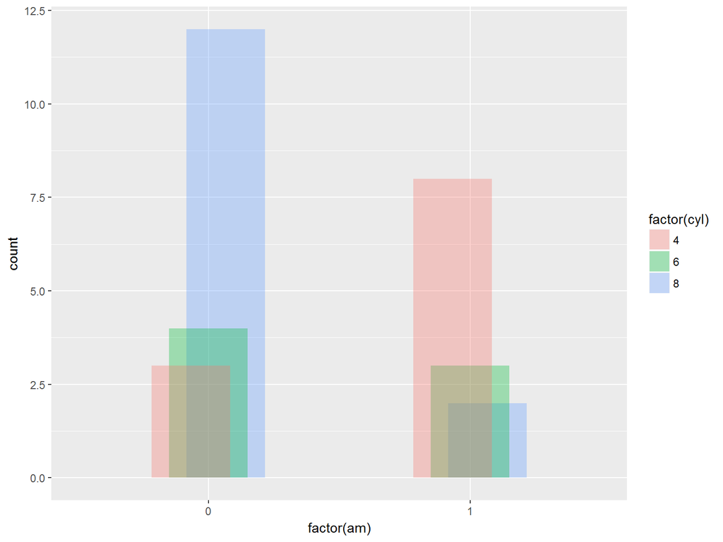

## geometria jitter

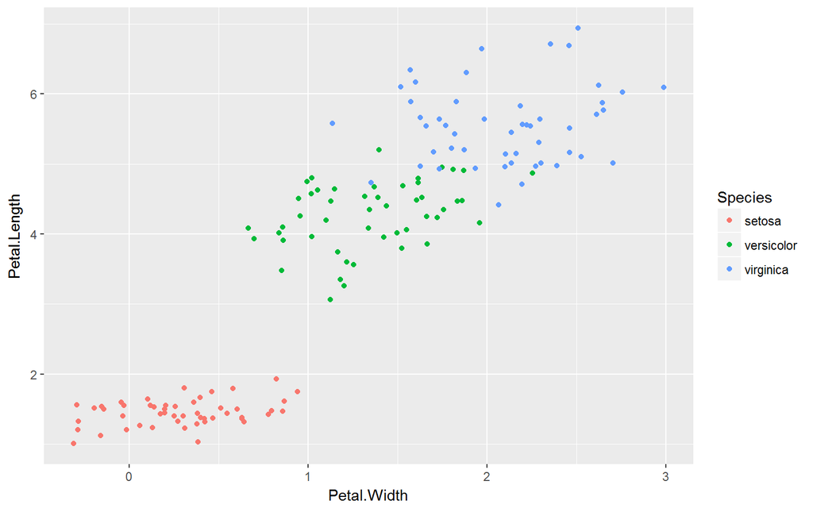

## Pozycja jitter

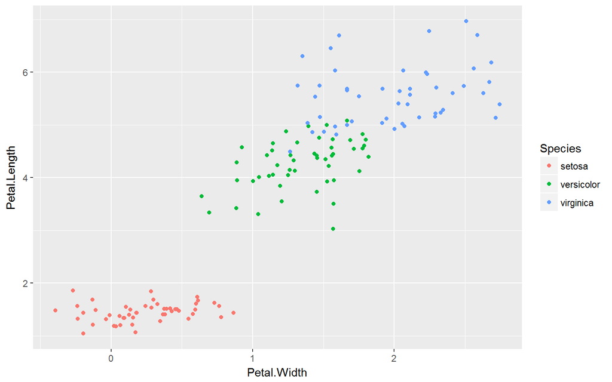

## Geometria histogram

Histogram jest specjalną modyfikacją geometrii **geom_bar**, dlatego wszystkie metody, pozycje itp. stosowane dla wykresów słupkowych mogą być stosowane dla histogramów.

Dodatkowym argumentem specyficznym dla histogramów jest **binwidth** określający szerokość przedziałów dla grupowanej zmiennej.

Domyślną jednostką osi OY są ilości wystąpień, aby otrzymać wykres częstości należy nadpisać wartość **y** w estetyce na **..density..**.

## Histogram gęstości

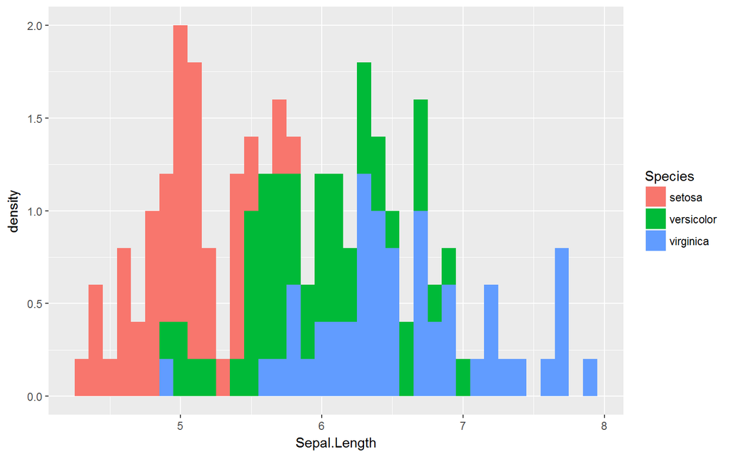

## Poziomy zmiennej na histogramie

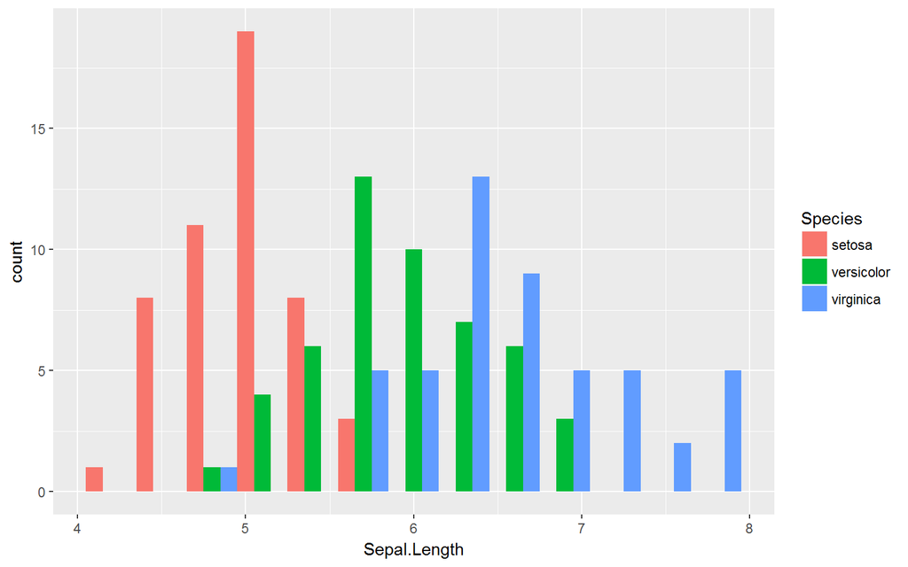

## Liniowy wykres częstości

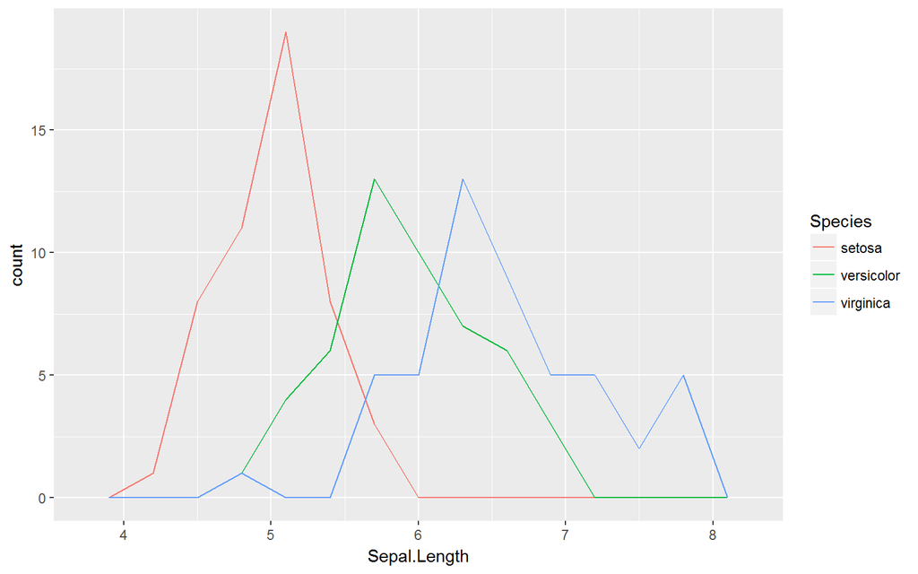

## Skale

Aby zmienić sposób mapowania konkretnych estety, możemy ręcznie zmienić skale. Przykładowymi skalami są:

- scale_x…; scale_y…: skale dla osi OX i OY.
- scale_color…, scale_fill…: skale dla kolorów.
- scale_shape…, scale_linetype…: skale dla kształtów, typów lini.

Jeśli to możliwe. skale określają też czy skala jest ciągła czy dyskretna.

## limits, breaks, expand, labels

## limits, breaks, expand, labels

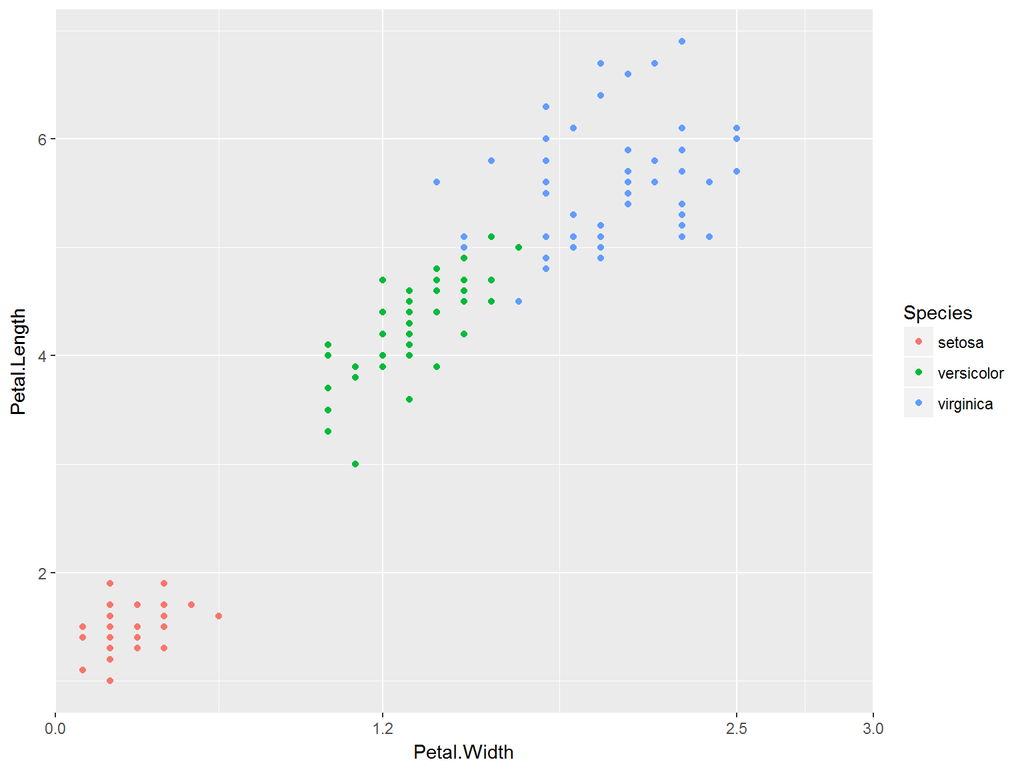

## Skale kolorów dyskretnych

## Skale kolorów dyskretnych

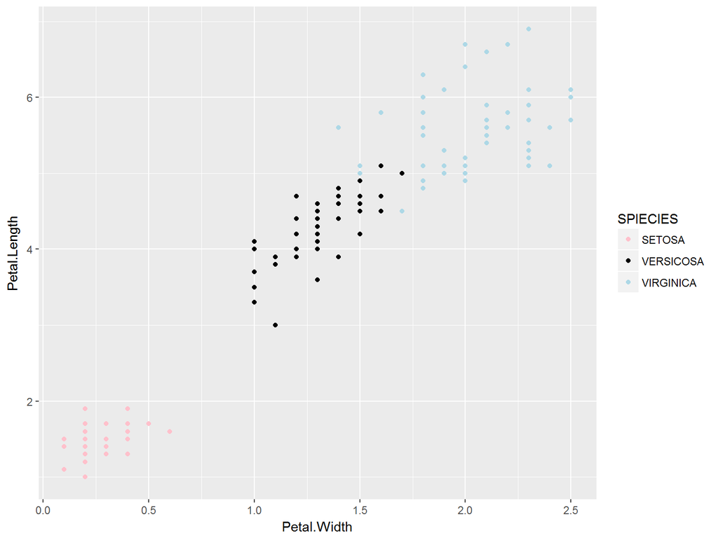

## Skale kolorów ciągłych i tytuł legendy

## Zmienne ciągłe na osiach OX i OY

[figure not shown]

## Zmienne ciągłe jako kolor

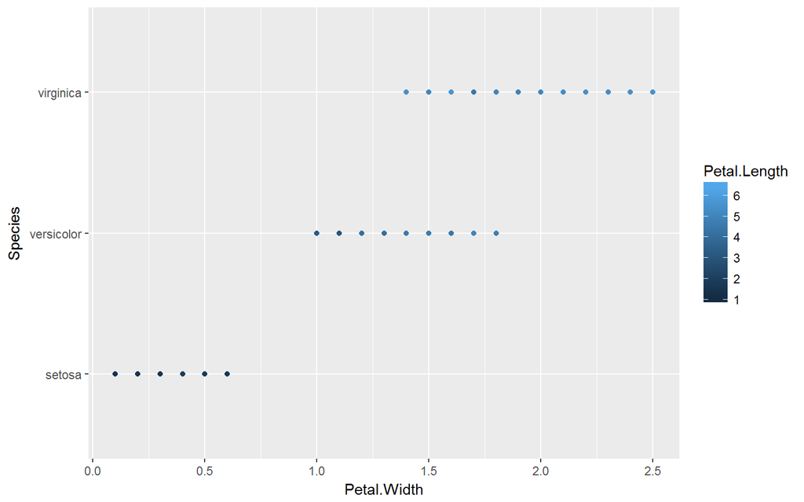

## Zmienna kategoryczna jako kształt

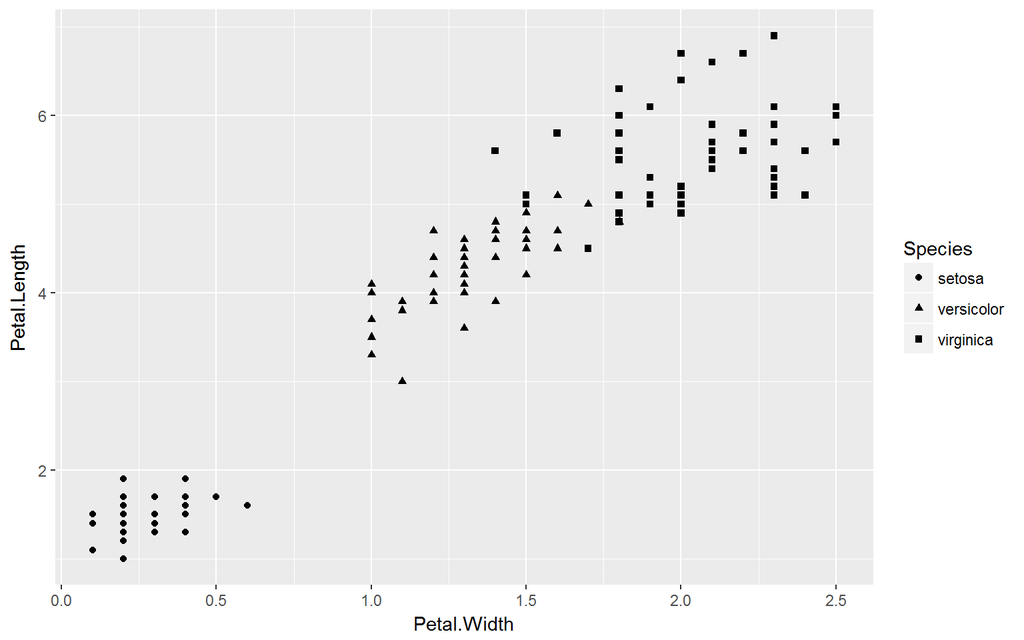

## Zmienna kategoryczna jako kształt i kolor

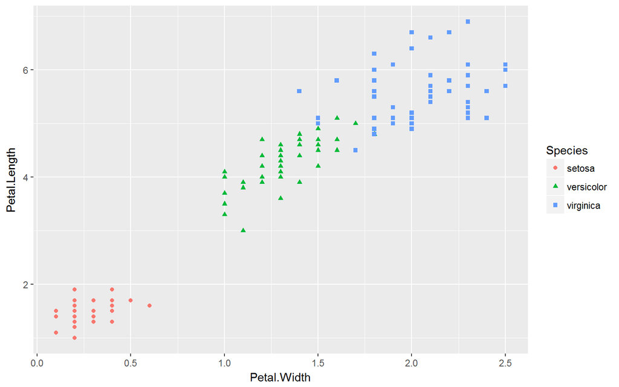

## Ćwiczenia

2. Dla danych **mtcars** stworzyć histogram spalania z rozróżnieniem na samochody o różnych ilościach cylindrów. Proszę wybrać takie arumenty, aby najlepiej było widać obserwowane rozkłady w grupach.
3. Dla danych **mtcars** stworzyć wykres zależności ilości cylindrów, mocy oraz spalania. Dobrać estetyki oraz skale, tak aby najlepiej zobrazować tę zależność.
4. Dla danych **diamonds** stworzyć wykres zależności ilości ceny, klarowności oraz wagi. Dobrać estetyki oraz skale, tak aby najlepiej zobrazować tę zależność.